# Lab 5

Ryan Pate

4/15/2021

1. Are there some days of the week where more accidents happen than the others?

   Friday, Saturday, and Sunday appear to have the most fatal accident occurrences.

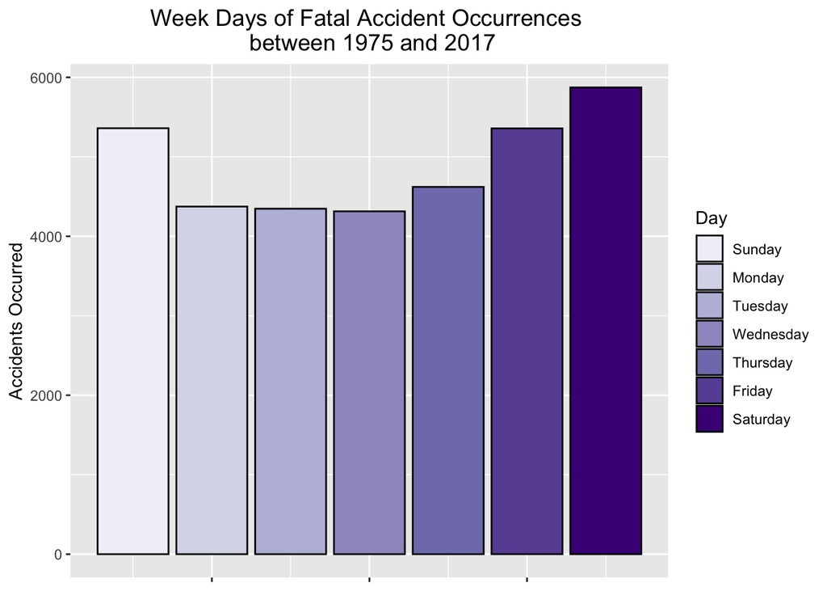

   ```r
     ggplot(acc, aes(x=DAY_WEEK, fill=factor(DAY_WEEK))) +
     geom_bar(width=0.9, color="black") +
     labs(title= "Week Days of Fatal Accident Occurrences \n between 1975 and 2017", x=NULL, y="Accidents Occurred") +
     theme(plot.title = element_text(size=14, hjust=0.5)) +
     theme(axis.text.x=element_blank()) +
     scale_fill_brewer(palette="Purples", labels=c("Sunday","Monday", "Tuesday", "Wednesday", "Thursday", "Friday",        "Saturday")) +
     labs(fill="Day")
   ```

2. Create a data frame containing the persons who are fatally hurt in the accidents.

   ```r
   fatal <- subset(pers, INJ_SEV == 4)
   ```

3. Create a data frame containing the most dangerous vehicle make in each state. The number of persons fatally hit in the vehicle make is used to assess the (non-)safety of a make. Make sure to handle the missing values appropriately.

   ```r
   group <- fatal %>%
     group_by(STATE, MAKE) %>%
     summarise(count = n())
   highest <- group %>%
     na.omit() %>%
     group_by(STATE) %>%
     filter(count == max(count))
   ```

4. Create a map, and label each state with the most dangerous vehicle. Discuss the definition of the most dangerous vehicle, and what you find from the map.

   In this context, the “most dangerous” vehicle make has the most fatalities from the USDOT’s fatality reports between 1975 and 2017. It appears that the makes that are the most dangerous in each state are 12 (Ford), 20 (Chevrolet), 37 (Honda), and 49 (Toyota). However, these makes are extremely commonly driven, so they do not necessarily accurately represent the most dangerous cars, as this data does not consider the disparity between the frequency of different makes being driven.

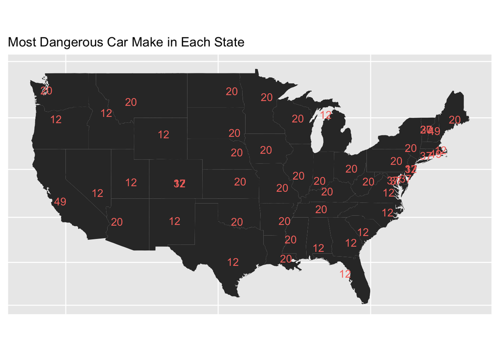

   ```r
   states <- map_data("state")

   highest$STATE <- as.character(highest$STATE)
   statesnew <- right_join(highest, codes, by = c("STATE" = "State Code"))
   statesnew$`State Name` <- tolower(statesnew$`State Name`)
   statesclean <- subset(statesnew, select = c("STATE", "MAKE", "count", "County Name", "State Name"))

   joined <- statesclean %>%
     group_by(STATE, MAKE) %>%
     left_join(states, by = c("State Name" = "region"))

   text <- joined %>%
     group_by(`State Name`, `MAKE`) %>%
     summarise(long = mean(long), lat = mean(lat)) %>%
     na.omit()
   ggplot(states, aes(long, lat)) +
     geom_polygon(aes(group=group)) +
     coord_map() +
     geom_text(aes(label = MAKE, color="white"), data = text) +
     labs(title="Most Dangerous Car Make in Each State", x=NULL, y=NULL) +
     theme(axis.text = element_blank(), axis.ticks = element_blank(), legend.position = "none")
   ```

5. Join the accident and person table (work out which variable(s) to use).

   ```r
   both <- inner_join(acc, pers, by= c("ST_CASE" = "ST_CASE"))
   ```

6. Tally the number of accidents by day of the week (DAY_WEEK), hour of the day (HOUR) and gender (SEX). Visualize the results and explain what you find.
7. Now plot a choropleth map of the number of deaths on a county level. Also explain what you find.

   My machine would not run this code, but this is what I had. I believe I did something wrong in joining the dataframes, because the total fatalities was only 37,133 rows, and my joined data frame had over 16,000,000.